# Primi passi di data science

Previsioni con metodi statistici

Nicola Lunardon

19 Febbraio 2021

# Contenuti

1. La previsione
2. Strumenti previsivi
   - Modello di regressione lineare
   - Alberi di classificazione

# La previsione

# Generalità

- Fare previsioni è intuitivo
- Alcuni esempi
  - Prevedere l’altezza dei figli al raggiungimento del massimo sviluppo disponendo dell’altezza di uno dei genitori
  - Prevedere il volume di legno di un albero sulla base dell’altezza e del diametro
  - Prevedere la specie di fiori sulla base delle caratteristiche fisiche dei petali
- Prevedere ha a che fare con il futuro
  - fare delle ipotesi/supposizioni su quello che avverrà

# Generalità (cont.)

- Riflettendo possiamo individuare due elementi
  - Il fenomeno da prevedere, l’oggetto della previsione
    - altezza del figlio/volume/specie di appartenenza
  - Gli elementi utilizzati per fare la previsione
    - altezza di uno dei genitori/altezza e diametro tronco/caratteristiche fisiche dei petali
- In gergo statistico
  - Variabile risposta: è il fenomeno da prevedere
  - Variabili esplicative: l’insieme degli elementi utilizzati che consentono di spiegare (e prevedere) la risposta
  - Dati/insieme di dati/**dataset**: l’insieme delle variabili risposta ed esplicative

# I dati

- I dati derivano da rilevando le variabili di interesse presso un certo numero, $n$, di unità statistiche
  - Esempio altezze
    - l’unità statistica è la coppia padre-figlio
    - le variabili di interesse sono l’altezza del padre e del figlio
  - Esempio volume tronco
    - l’unità statistica è l’albero
    - le variabili di interesse sono l’altezza del tronco ed il suo diametro
  - Esempio delle specie
    - l’unità statistica è il fiore
    - le variabili di interesse sono relative a determinate caratteristiche dei petali
- I dati vengono organizzati in una tabella ordinata, o matrice, che ha un numero di
  - righe pari al numero di unità statistiche, quindi $n$
  - colonne pari a $k+1$, ovvero al numero di variabili esplicative, $k$, più la variabile risposta

# I dati (cont.)

- Nell’esempio delle altezze disponiamo delle misurazioni delle altezze (in cm) di 1078 coppie padre-figlio
  - 10 unità statistiche dell’insieme di dati

```
##  Altezza padre Altezza figlio
##          162.6          149.4
##          158.1          158.0
##          162.4          158.4
##          164.4          157.0
##          152.8          160.7
##          157.6          160.6
##          163.4          160.2
##          161.8          160.0
##          165.2          161.5
##          167.4          159.9
```

- Nell’esempio dei ciliegi disponiamo delle misurazioni del volume del tronco (in metri cubi), circonferenza (in metri) e altezza (in metri) di 31 alberi di ciliegio
  - 10 unità statistiche dell’insieme di dati

```
##  Diametro Altezza Volume
##   0.21248    21.0  0.309
##   0.22016    19.5  0.309
##   0.22528    18.9  0.306
##   0.26880    21.6  0.492
##   0.27392    24.3  0.564
##   0.27648    24.9  0.591
##   0.28160    19.8  0.468
##   0.28160    22.5  0.546
##   0.28416    24.0  0.678
##   0.28672    22.5  0.597
```

- Nell’esempio dei fiori disponiamo dell’informazione circa la specie di appartenza degli Iris e misurazioni della lunghezza e larghezza del petalo (in millimetri)
  - 10 unità statistiche dell’insieme di dati

```
##  Lunghezza.Petalo Larghezza.Petalo     Specie
##               1.5              0.2     setosa
##               4.5              1.3 versicolor
##               4.5              1.5 versicolor
##               5.1              1.5  virginica
##               1.6              0.2     setosa
##               6.1              1.9  virginica
##               5.6              2.4  virginica
##               4.2              1.3 versicolor
##               4.0              1.3 versicolor
##               1.4              0.2     setosa
```

# Tipi di previsione

- Possiamo prevedere fenomeni
  - Quantitativi: la variabile risposta è di tipo numerico
    - Esempio altezze e volume del tronco dei ciliegi
  - Qualitativi: la variabile risposta si manifesta con modalità che si possono descrivere con espressioni verbali
    - Esempio specie dei fiori
    - in questo caso la previsione prende il nome di **classificazione**

# Come prevedere

- Diagramma di dispersione dei dati sulle altezze

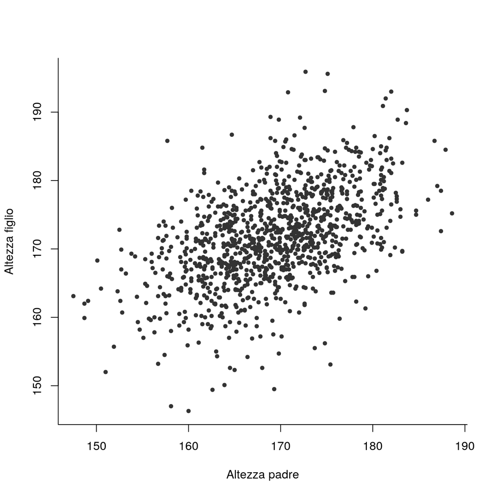

- Come utilizzare i dati di cui disponiamo?
  - Elaborazione soggettiva basata su esperienze personali
    - “se il padre è alto più di 180 cm, allora il figlio avrà altezza maggiore o uguale a quella del padre”
    - Il rettangolo individua l’insieme di possibili valori previsti secondo questa regola
    - Criticità: è soggettiva e non dice come scegliere esattamente all’interno del rettangolo

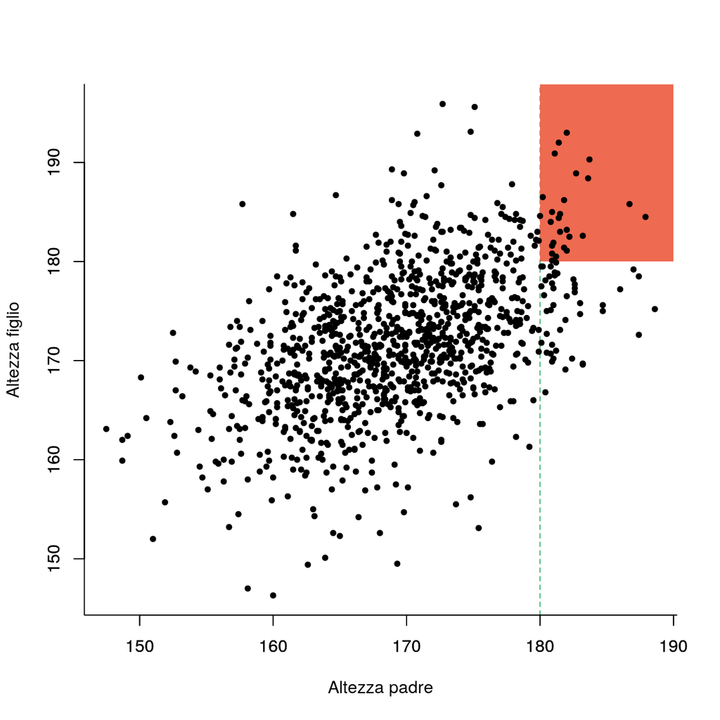

  - Elaborazione quanto più oggettiva possibile

# La previsione in ambito statistico

- In ambito statistico le previsioni si basano su modelli matematici (talvolta anche algoritmi)
  - Logica trasparente
  - Risultati riproducibili e coerenti nel tempo
- Nei modelli matematici si postula una relazione tra la variabile risposta e le variabili esplicative
  - Fase di stima o apprendimento: si usano i dati a disposizione per rendere il modello (la relazione postulata) coerente con i dati disponibili
  - Nell’esempio delle altezze potremmo postulare una relazione lineare tra l’altezza del padre e del figlio
    $$\text{altezza figlio}= \alpha + \beta\,\text{altezza padre}$$
  - La fase di apprendimento si riduce a trovare i coefficienti della retta che sono più coerenti con l’insieme di dati

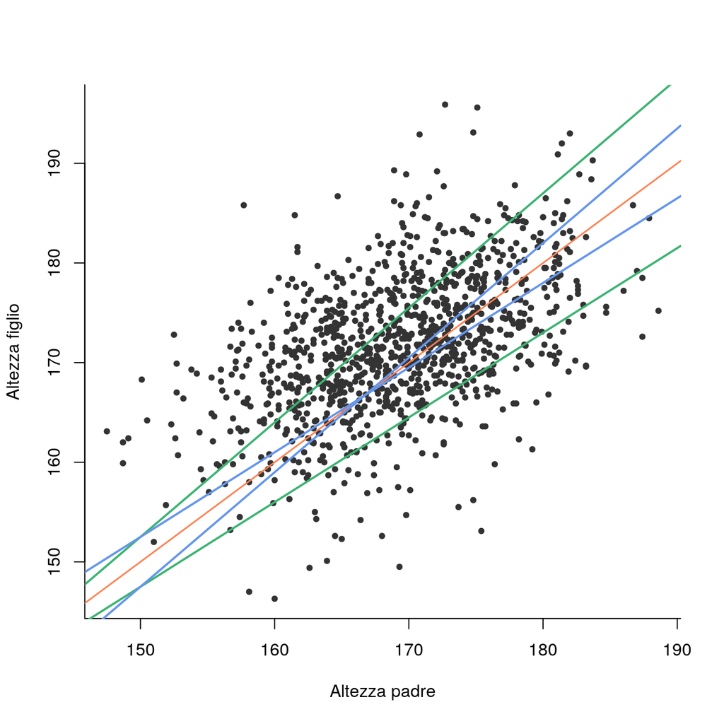

  - Fase di previsione: utilizzo il modello ottenuto nella fase di stima, quindi il modello stimato, per fare la previsione
- Nella fase di stima si dispone sia della variabile risposta che esplicativa
- Nella fase di previsione si dispone del valore della sola variabile esplicativa e si utilizza il modello stimato per prevedere il valore della variabile risposta
  - Lo scopo è stimare un modello per prevedere quello che non si conosce

# Strumenti previsivi

# Modello di regressione lineare

- Adatto a fare previsioni di fenomeni quantitativi
  - Esempi: altezze padre-figlio e volume del tronco dei ciliegi
- Consideriamo il caso in cui ci sia una sola variabile esplicativa, come nell’esempio delle altezze.
  - Modello di regressione lineare semplice
- Si postula una relazione lineare tra la variabile risposta, indicata con $y$, e la variabile esplicativa, indicata con $x$:
  $$y=\alpha + \beta x + \epsilon$$
  - La quantità
    $$\alpha+\beta x$$
    è detta **retta di regressione**
  - $\epsilon$ è un termine di errore che tiene conto di tutto ciò quello che la *retta di regressione* non riesce a cogliere della variabile risposta
  - Supponiamo che $\alpha=0$ e $\beta=1$

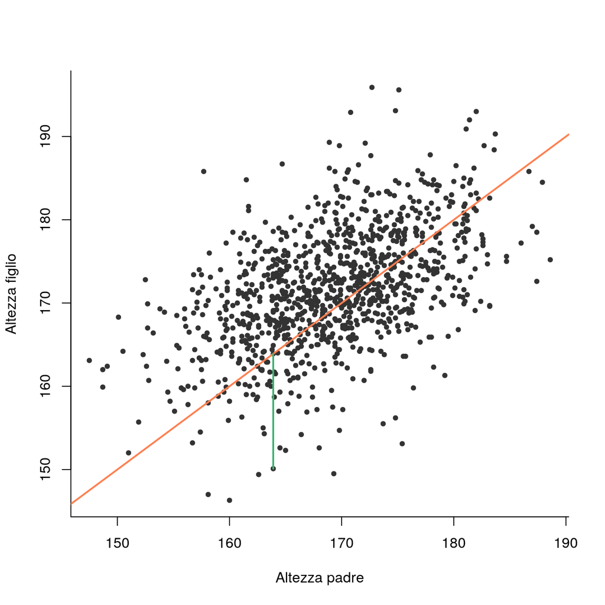

# Stima del modello di regressione lineare

- Nel modello di regressione si stimano i coefficienti, $\alpha$ e $\beta$, che determinano la retta di regressione
- Il criterio che si utilizza è quello di rendere minima la somma dei quarati degli scarti tra i punti e la retta di regressione
  - Il criterio è chiamato criterio dei minimi quadrati
- Rappresentazione grafica nell’esempio delle altezze
  - I segmenti verdi rappresentano gli scarti tra ciascun punto e la retta di regressione
    - (si riportano solo 100 scarti scelti casualmente)

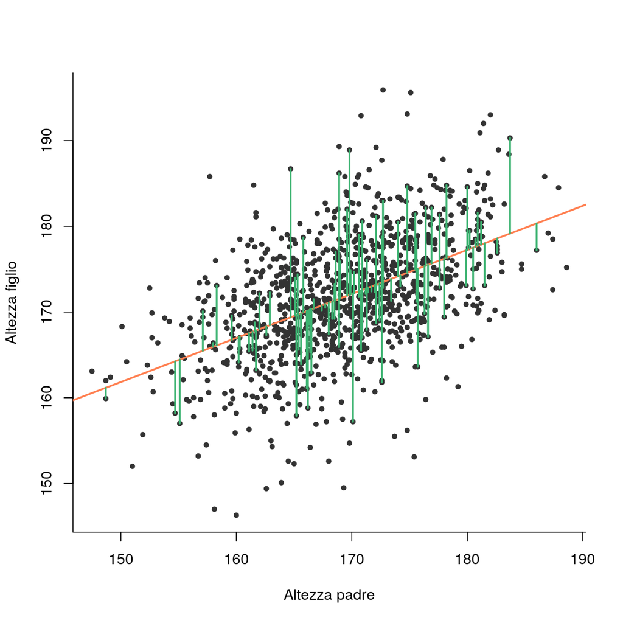

# Previsione del modello di regressione lineare

- Terminata la fase di stima si ottiene la retta di regressione stimata

$$\hat\alpha+\hat\beta x$$

- Possiamo prevedere la variabile risposta di un’unità statistica avente valore della variabile esplicativa pari a $x^*$
  - La previsione fornita dal nostro modello è

    $$\hat\alpha+\hat\beta x^*$$
  - La previsione si trova sulla retta di regressione stimata
- Nell’esempio delle altezze, abbiamo che la retta di regressione stimata è
  $$84.76+0.51x$$
- Qual è l’altezza prevista per un figlio che ha un padre con altezza pari a 190 cm?
  $$84.76+0.51\times 190 \approx 181.7$$
- Graficamente

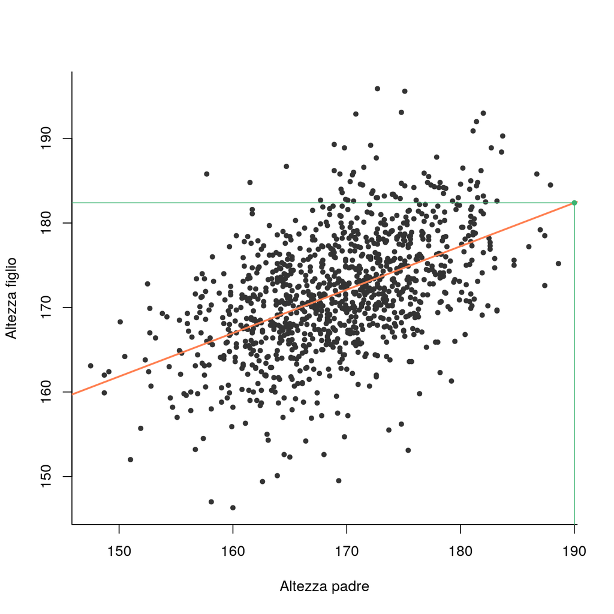

# Valutazione della bontà delle previsioni

- Potremmo usare la somma degli scarti tra valori veri e valori previsti dal modello al quadrato
  - Il valore dipende dall’unità di misura
    - Per esempio, valori diversi se utilizzo l’altezza in centimetri o in metri
- È possibile utilizzare l’indice di determinazione, indicato con $R^2$
  - Mette in relazione
    - Le previsioni effettuate dal nostro modello (figura a sinistra)
    - Le previsioni fatte utilizzando la media della variabile risposta (figura a destra)

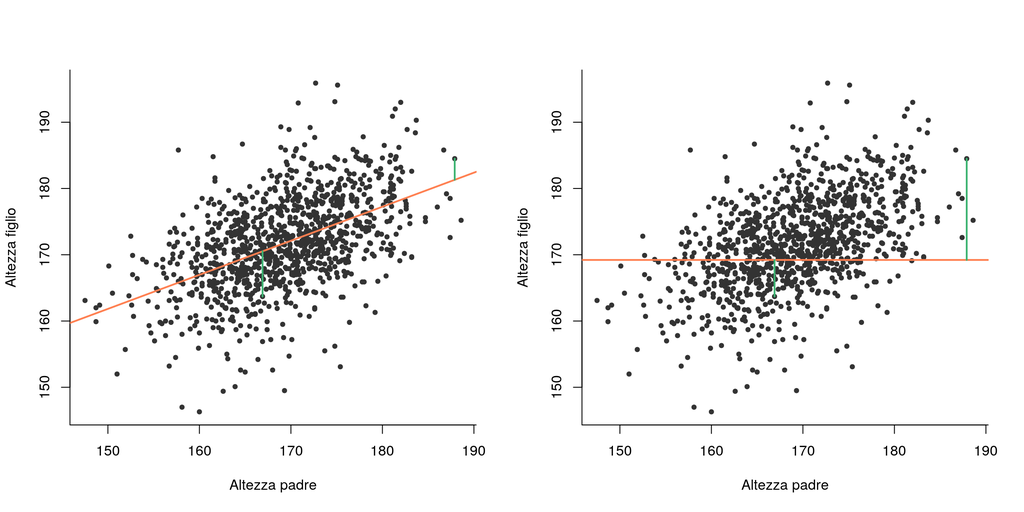

  - Assume valore tra 0 e 1: più alto è il valore e più accurate sono le previsioni rispetto a quelle fatte utilizzando la media

# Modello di regressione lineare multipla

- La differenza con il modello di regressione lineare semplice risiede nel numero di variabili esplicative
  - regressione lineare multipla: $k$ variabili esplicative, con $k>1$
    - $x_1,x_2,\ldots,x_k$
- La relazione che postuliamo tra la variabile risposta e le $k$ variabile esplicative è sempre di tipo lineare
  $$y=\alpha+\beta_1x_1+\beta_2x_2+\cdots+\beta_kx_k + \epsilon$$
- In questo caso $\alpha+\beta_1x_1+\beta_2x_2+\cdots+\beta_px_p$ è
  - un piano di regressione se $k=2$
  - un iperpiano di regressione se $k>2$
- Il criterio per la stima dei parametri rimane lo stesso visto per la regressione semplice, ovvero i minimi quadrati
- La previsione si ottiene in modo analogo a quello visto per la regressione semplice
  - L’iperpiano di regressione stimato è
    $$\hat\alpha+\hat\beta_1x_1+\hat\beta_2x_2+\cdots+\hat\beta_kx_k$$
  - Il valore previsto per un’unità per la quale le variabili esplicative sono $x_1^*, x_2^*,\ldots,x_k^*$ è
    $$\hat\alpha+\hat\beta_1x^*_1+\hat\beta_2x^*_2+\cdots+\hat\beta_kx^*_k$$
  - Il valore previsto giace sull’iperpiano di regressione stimato

# Modello di regressione lineare multipla: esempio

- Dati relativi al volume del tronco di 31 alberi di ciliegio
  - variabile risposta: volume del tronco (metri cubi)
  - variabili esplicative:
    - altezza (metri)
    - circonferenza misurata ad un metro da terra (metri)
- Prima di stimare il modello, attingiamo alle nostre conoscenze
  - Con un buon grado di approssimazione, il tronco di un albero è un cilindro
    $$\text{volume tronco} = \text{altezza}\times\pi\times\text{raggio}^2 = \text{altezza}\times\pi\times\frac{\text{diametro}^2}{4}$$
  - Prevediamo il volume del tronco usando questa relazione e confrontiamo con i volumi misurati

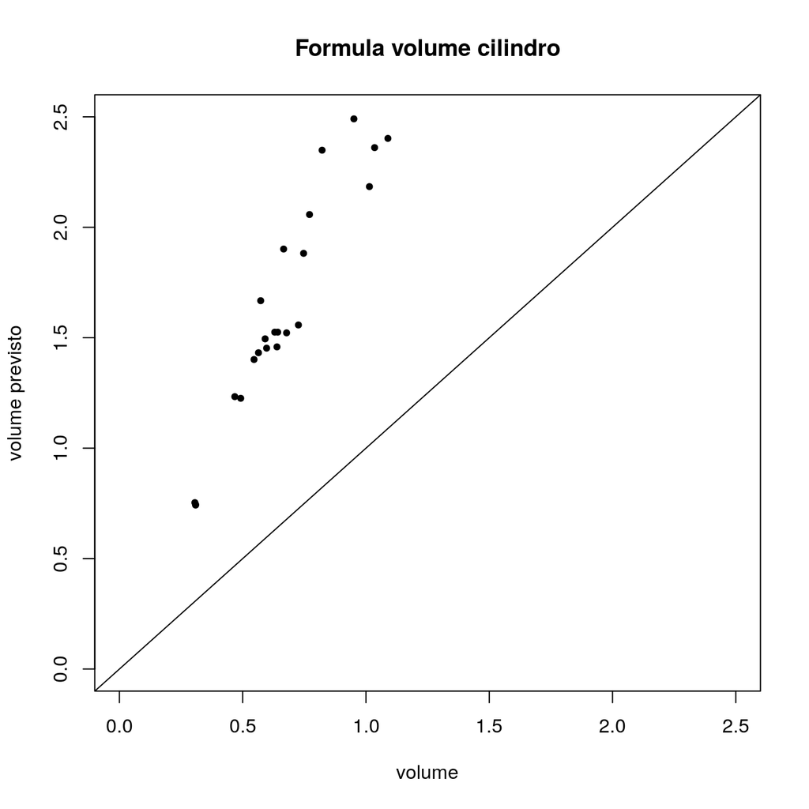

  - Il volume previsto è sempre più grande rispetto a quello misurato sull’albero
    - Ascrivibile al fatto che il diametro del tronco non è costante su tutta l’altezza dell’albero
- Utilizziamo un modello di regressione lineare
  $$\text{volume tronco} = \text{altezza} + \text{diametro} + \epsilon$$
- Possiamo fare di meglio partendo dalla formula del volume del cilindro
  $$\text{volume tronco} = \text{altezza}\times\pi\times\frac{\text{diametro}^2}{4}$$
- La relazione tra la variabile risposta e le esplicative non è lineare, ma possiamo applicare una trasformazione logaritmica
  $$\log\text{volume tronco} = \log\pi - \log 4 + \log\text{altezza} + 2\log\text{diametro}$$
- È sensato pensare ad un modello di regressione lineare utilizzando le variabili trasformate
  $$\log\text{volume tronco} = \alpha + \beta_1\log\text{altezza} + \beta_2\log\text{diametro}+\epsilon$$
  - $\epsilon$ si prende carico del fatto che il tronco dell’albero non è esattamente cilindrico
- Differenza nelle previsioni tra i due modelli stimati

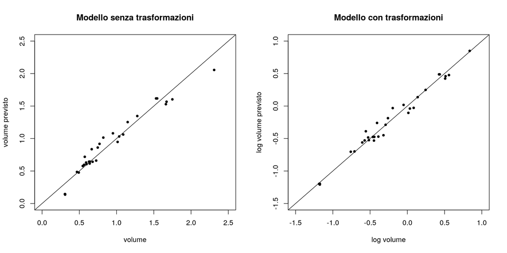

- Indice di determinazione $R^2$
  - Modello lineare senza trasformazioni: $R^2=0.95$
  - Modello lineare con trasformazioni: $R^2=0.98$

# Alberi decisionali

- Strumento adatto a fare previsioni di fenomeni quantitativi e qualitativi
  - Tratteremo solo alberi che prevedono fenomeni qualitativi
- Dati relativi alla specie di appartenenza di 150 esemplari di Iris (fiori)
  - Variabile risposta: specie di appartenenza
    - Setosa
    - Virginica
    - Versicolor
  - Variabili esplicative: lunghezza e larghezza (in mm) dei petali
- Le tre specie di Iris (da sinistra: Setosa, Virginica e Versicolor)

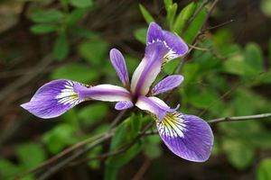

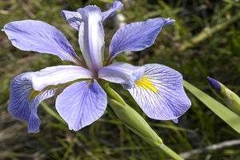

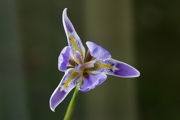

- Consideriamo le misurazioni relative alla lunghezza del petalo

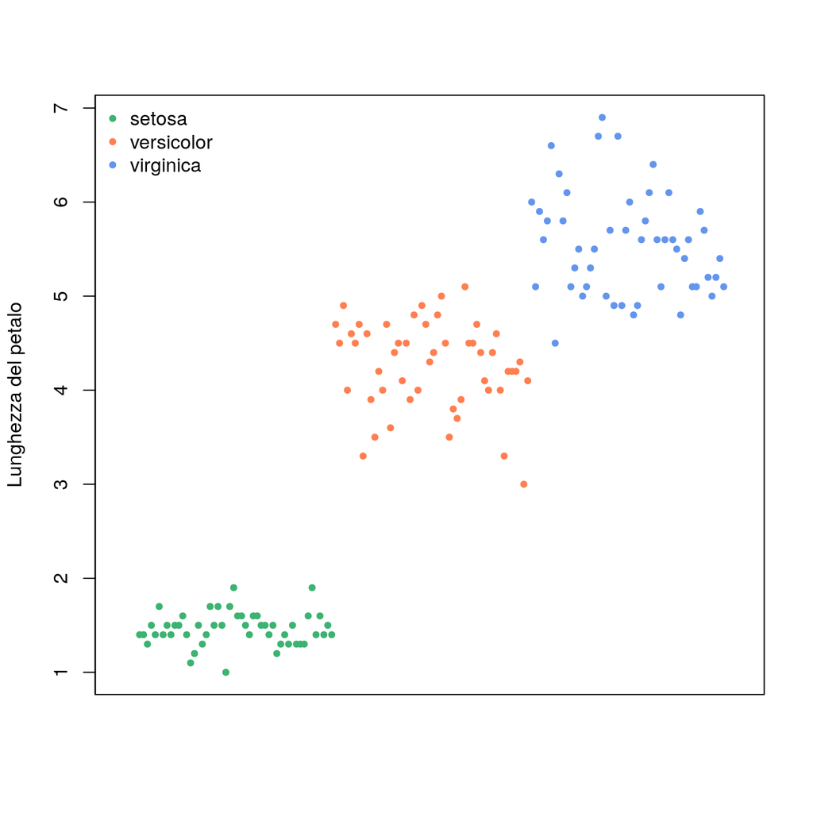

  - La specie setosa si può distinguere molto bene in base alla lunghezza del petalo, ma anche versicolor e virginica mostrano un buon grado di separazione
  - Sulla base di questo grafico potremmo fare le nostre previsioni
    1. Se lunghezza petalo inferiore a 2.5 mm $\rightarrow$ setosa
    2. Se lunghezza petalo compresa tra 2.6 mm e 5 mm $\rightarrow$ versicolor
    3. Se lunghezza petalo superiore a 5.1 mm $\rightarrow$ virginica
- Un albero decisionale fa esattamente questo
  - Procedimento ben definito e riproducibile
- Il risultato di un albero decisionale

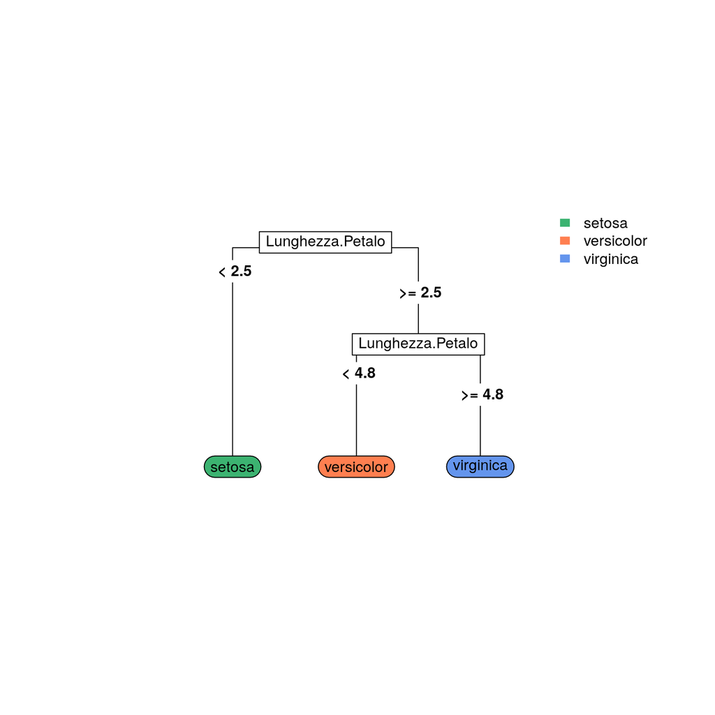

- L’albero fornisce una previsione basata su regole decisionali che coinvolgono la varibile esplicativa
- La rappresentazione dell’albero va letta dall’alto verso il basso
  - I riquadri rettangolari (non colorati) sono detti **nodi**
    - Riportano il nome della variabile esplicativa utilizzata per compiere la decisione
  - Da ogni nodo partono un ramo destro e un ramo sinistro
    - Riportano la condizione in base alla quale l’albero effettua la decisione
  - Le **foglie** sono nodi da cui non partono rami
    - Riportano la previsione dell’albero

# Stima di un albero decisionale

- Ci sono vari algoritmi che permettono di stimare alberi decisionali
  - vedremo la logica dell’algoritmo di partizione ricorsiva binaria
- Consideriamo i dati sugli Iris e cerchiamo di capire come si è arrivati al risultato mostrato
- Passo
  1. La prima decisione

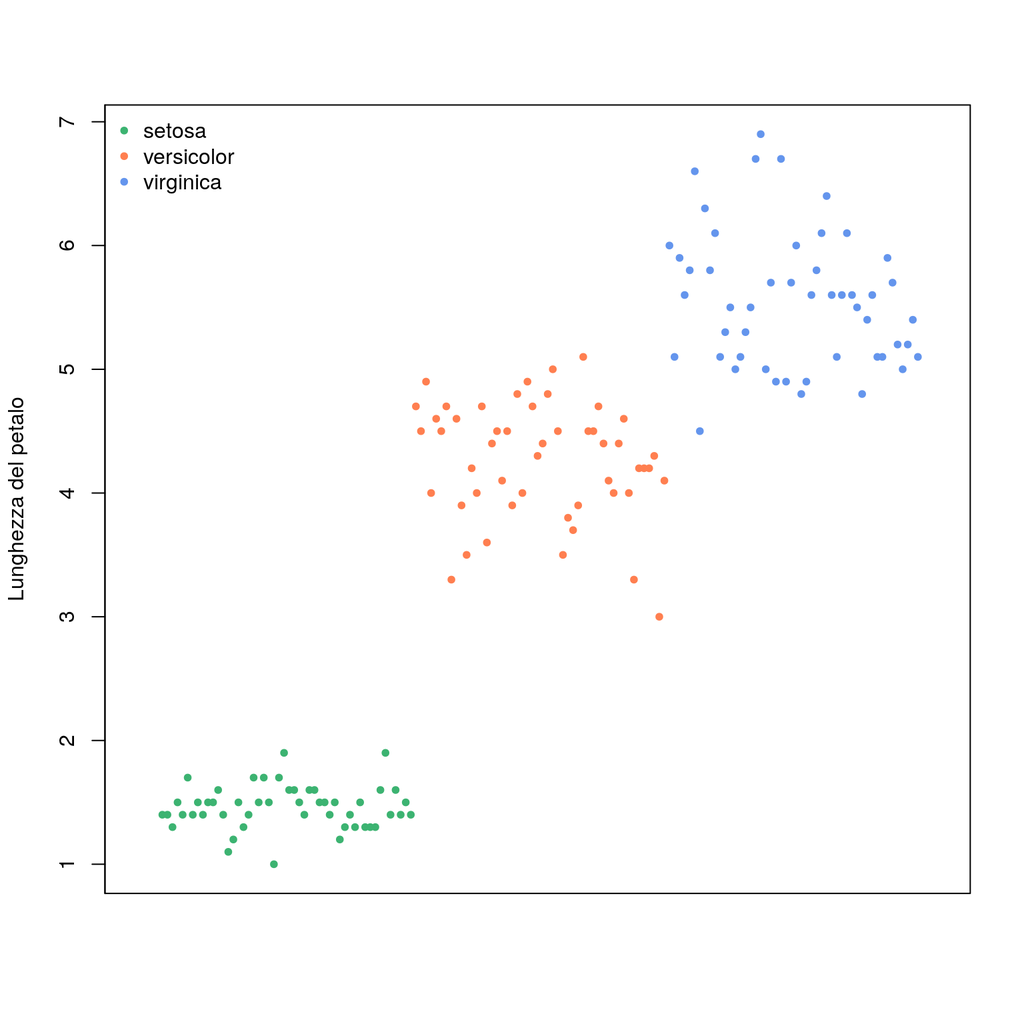

     - devo decidere rispetto a quale valore della lunghezza del petalo fare la mia decisione
     - la logica è quella di riuscire a trovare un valore che mi permetta di fare le previsioni più corrette possibili
     - dal grafico è chiaro che posso prevedere correttamente tutti gli esemplari di Iris Setosa se scelgo opportunamente il valore rispetto al quale fare la decisione
     - scelgo quindi il valore 2.5
       - se lunghezza petalo inferiore a 2.5 $\rightarrow$ setosa
       - se lunghezza petalo superiore o uguale a 2.5 $\rightarrow$ versicolor se la proporzione di versicolor supera quella dei virginica; virginica altrimenti

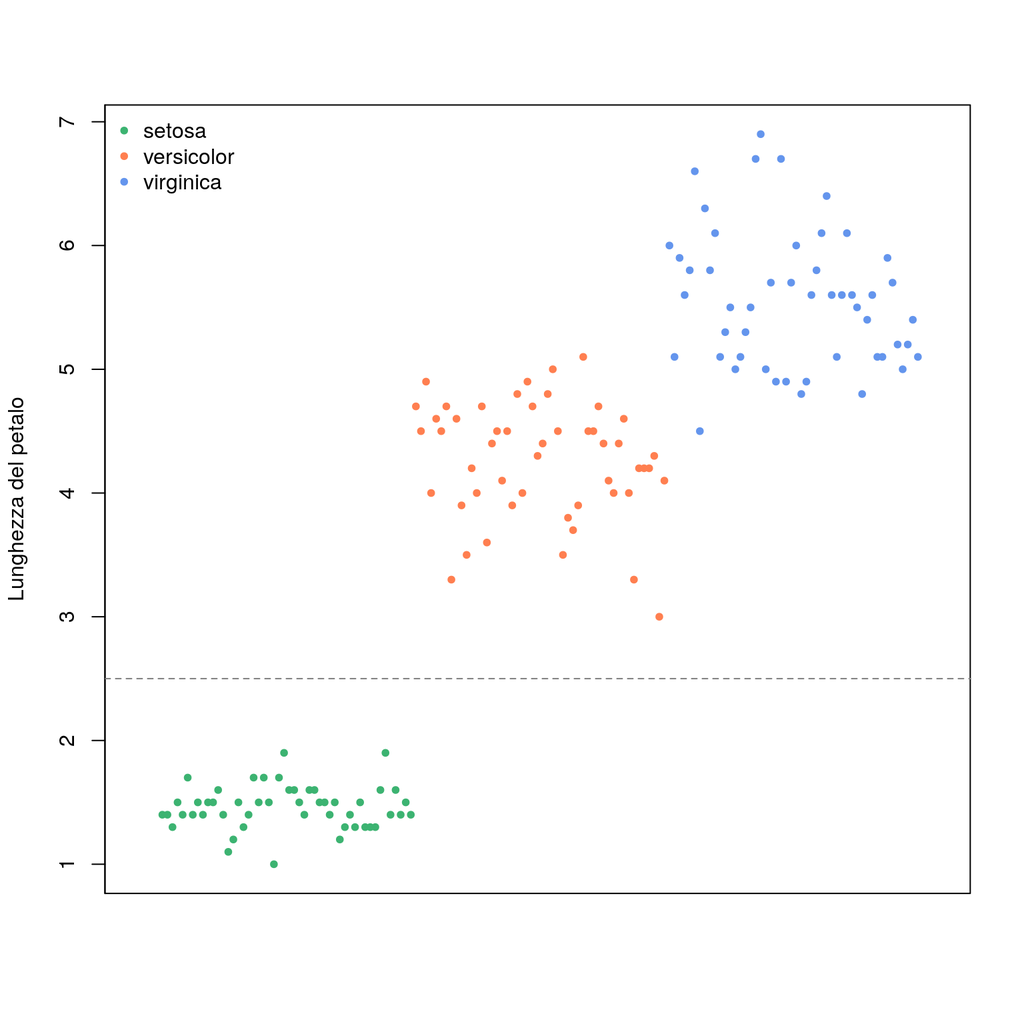

  2. La seconda decisione
     - Dal momento che tutti gli esemplari di setosa sono previsti correttamente, non farò ulteriori decisioni per valori di lunghezza del petalo inferiore a 2.5
     - Devo effettuare una decisione per valori di lunghezza del petalo maggiori o uguali a 2.5, in modo tale da prevedere quanto più correttamente gli esemplari sia di virginica che di versicolor
     - Decido per il valore 4.8
       - se lunghezza petalo superiore o uguale a 4.8 $\rightarrow$ virginica (la proporzione di virginica è superiore a quella di versicolor quando considero gli esemplari con lunghezza petalo superiore o uguale a 4.8)
       - se lunghezza petalo superiore o uguale a 2.5 e inferiore a 4.8 $\rightarrow$ versicolor (la proporzione di versicolor è superiore a quella di virginica quando considero gli esemplari con lunghezza petalo superiore o uguale a 2.5 ed inferiore a 4.8)

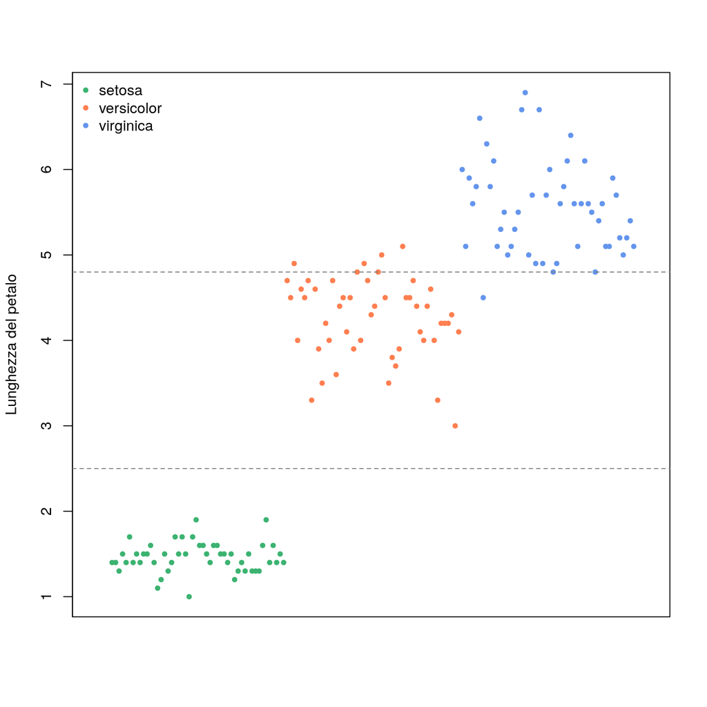

  3. Non effettuo ulteriori decisioni perchè non apporterebbero un vantaggio significativo
- Riassumendo, l’algoritmo
  - Effettua le decisioni in modo tale da fare previsioni migliori rispetto a quelle del passo precedente
  - Non cambia mai le decisioni fatte ad un passo precedente
  - Prevede la specie che presenta la proporzione maggiore di esemplari che soddifano la regola su cui si basa la decisione

# Stima di alberi decisionali (cont.)

- Quando disponiamo di più variabili esplicative, la logica dell’algoritmo rimane sempre la stessa
  - Effettua le decisioni per fare previsioni via via migliori
  - Ma valuta, ad ogni passo, quale variabile esplicativa porta ad un miglioramento maggiore
- Consideriamo ora anche la variabile esplicativa relativa alla larghezza del petalo

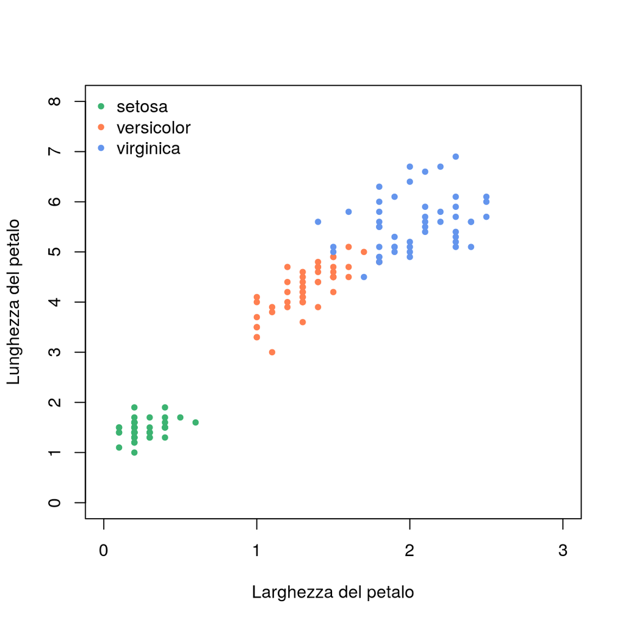

- Risultato dell’albero decisionale considerando le due variabili esplicative

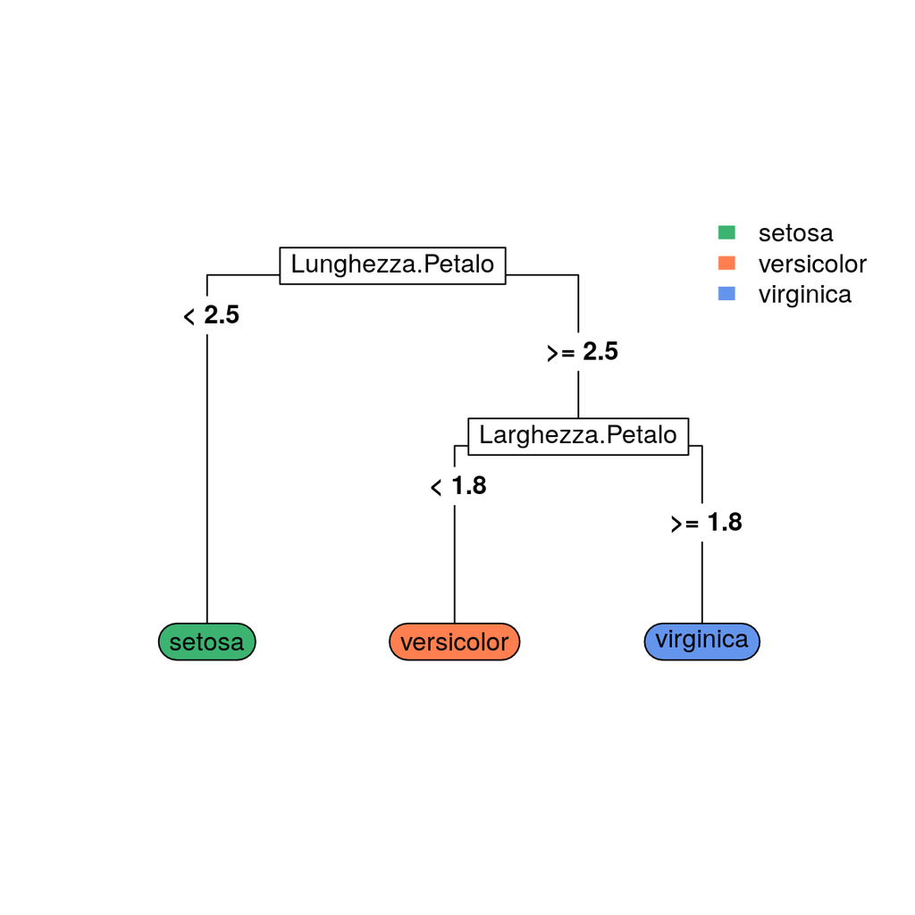

  - La prima decisione non cambia rispetto a quanto visto in precedenza
  - La seconda decisione viene fatta rispetto alla variabile esplicativa larghezza petalo
    - L’algoritmo ha verificato che effettuare la decisione rispetto a questa variabile porta a fare previsioni migliori rispetto agli esemplari delle specie virginica e versicolor

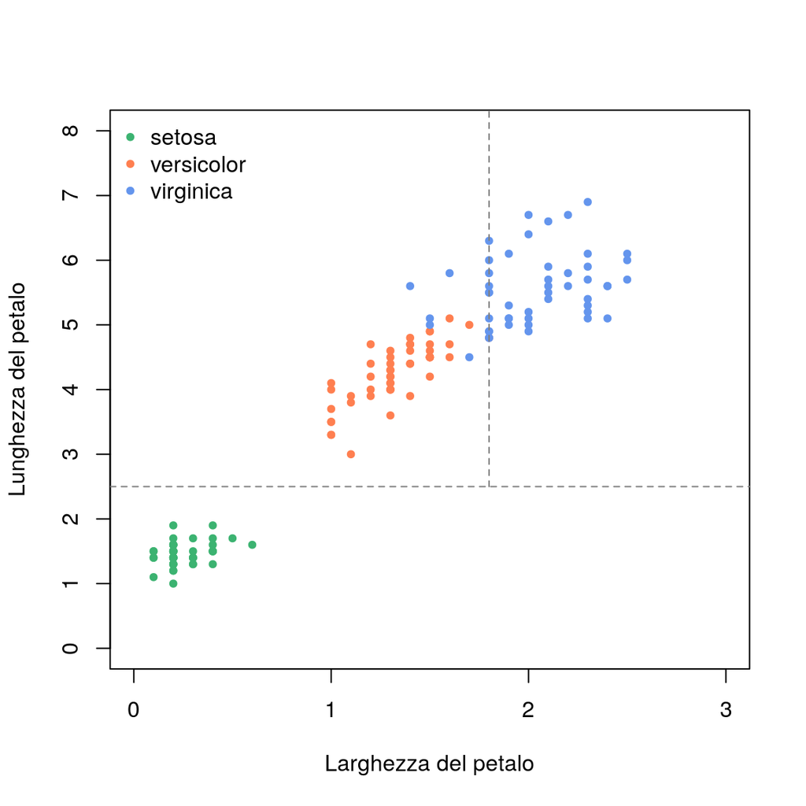

# Valutazione della bontà delle previsioni

- Quando usiamo un albero decisionale prevediamo una variabile qualitativa
  - Per valutare la bontà delle previsioni è possibile utilizzare la proporzione di corrette previsioni
    - Si ricavano dalla **matrice di confusione**: è una tabella che mette in relazione le previsioni dell’albero con i valori veri
      - A sinistra: matrice di confusione dell’albero decisionale con solo lunghezza petalo
      - A destra: matrice di confusione dell’albero decisionale con lunghezza e larghezza petalo

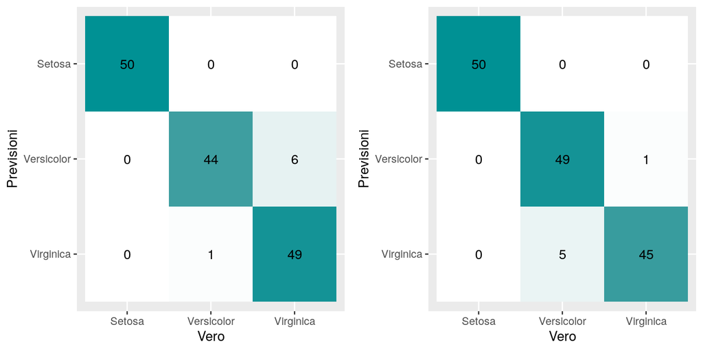

- La proporzione di corrette previsioni è data da
  - $(50+44+49)/150=0.953$ per l’albero basato sulla sola variabile “Lunghezza petalo”
  - $(50+45+49)/150=0.96$ per l’albero basato sulle variabili “Lunghezza petalo” e “Larghezza petalo”